# Gini Importance & Random Forest Backward Selection

Stu Field

2 May 2018

# 1 What is Gini Importance?

Every time a split of a node is made on variable `m` the *Gini Impurity* (`G`) criterion for the two child nodes is less than the parent node. Adding up the gini “losses” for each feature over all trees in the forest gives a fast variable importance that is often very consistent with the permutation importance measure. Thus `G` is calculated as:

$$G = \sum_{i=1}^{n_c} p_i(1 - p_i),$$

where $n_c$ is the number of classes in the target variable and $p_i$ is the ratio of this class. A convenient property of the Gini impurity metric `G` is that it allows one to calculate a *theoretical maximum* that is based **solely** on the initial class distribution:

```r
# @param x A vector of the initial true classes
gini_max <- function(x) {
  purrr::map_dbl(unique(x), function(.x)
    mean(.x == x) * mean(.x != x)) %>%
    sum() * length(x)                   # scale the sum by no. samples
}
```

## 1.1 Gini Example

For a two-class problem, the `G` is maximized at equal class proportions, and minimized for either homogeneous case. **Note:** the goal is to *minimize* `G`:

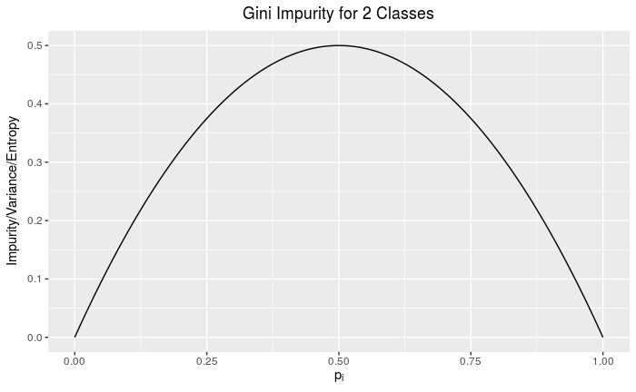

```r
theme_set(theme_gray())
gini_fun <- function(p) 2 * p * (1 - p)        # does this look familiar?
ggplot(data.frame(x = c(0, 1)), aes(x)) +
  stat_function(fun = gini_fun, geom = "line") +
  labs(x = expression(p[i]), y = "Impurity/Variance/Entropy") +
  ggtitle("Gini Impurity for 2 Classes") +
  theme(plot.title = element_text(hjust = 0.5))
```

And the *Gini Importance* (`I`) is calculated:

$$I = G_{parent} - G_{split1} - G_{split2}$$

# 2 Simulate Some Data

```r
set.seed(101)
n_per_group <- 50
n_features  <- 9
gini_data   <- c(1.5, 1.0, 0.5, 0.25, 0, 0 , 0, 0, 0) %>%  # effect sizes; 5 noise variables
  purrr::map_dfc(function(delta) {
    c(rnorm(n_per_group, mean = 0, sd = 1),
      rnorm(n_per_group, mean = delta, sd = 1))
  }) %>%
  set_names(paste0("F", 1:n_features)) %>%
  dplyr::mutate(class = rep(c("C1", "C2"), each = n_per_group) %>% factor()) %>%
  dplyr::select(class, everything())
dim(gini_data)
```

```
[1] 100  10
```

```r
head(gini_data)
```

| class | F1 | F2 | F3 | F4 | F5 | F6 | F7 | F8 | F9 |
| --- | --- | --- | --- | --- | --- | --- | --- | --- | --- |
| C1 | -0.3260365 | 0.2680658 | -0.1640324 | -1.1658569 | -0.3205369 | -1.27235813 | -0.3893127 | 0.02777378 | -1.4597361 |
| C1 | 0.5524619 | -0.5922083 | -1.3832751 | -0.2397987 | -2.0919208 | -0.66307158 | -1.0726485 | 0.14470549 | 0.3014991 |
| C1 | -0.6749438 | 2.1334864 | 0.4235113 | 1.1843827 | -1.8518319 | -0.29654313 | -0.3953464 | -0.23756438 | 0.3064595 |
| C1 | 0.2143595 | 1.1727487 | -0.7904889 | 0.2075084 | 0.4396653 | -0.57396643 | -0.8449876 | -0.74284806 | 0.3734142 |
| C1 | 0.3107692 | 0.7467610 | 1.2099248 | -0.0436326 | 0.1419048 | -0.02617408 | -0.6559405 | 0.26090560 | -0.2409354 |
| C1 | 1.1739663 | -0.2305087 | 0.8945168 | -0.9710775 | -0.8250591 | 0.25972722 | -2.5069914 | 0.42942714 | 0.9095359 |

```r
tail(gini_data)
```

| class | F1 | F2 | F3 | F4 | F5 | F6 | F7 | F8 | F9 |
| --- | --- | --- | --- | --- | --- | --- | --- | --- | --- |
| C2 | 1.7820149 | 0.1241511 | 1.0249407 | 1.3898384 | -0.9507383 | -0.7746895 | -0.8761140 | -0.1823818 | 0.8230549 |
| C2 | 0.7094743 | 0.9854393 | 1.1151452 | -0.7365448 | -1.1217938 | 0.1155307 | -1.1846459 | -0.2828838 | 0.4462732 |
| C2 | 1.0550954 | 0.2755068 | 0.1671837 | -0.4236668 | -0.1350762 | -1.0389777 | -0.5892051 | -0.2427077 | 1.5370221 |
| C2 | 2.8649932 | 2.9693701 | 1.2453288 | -1.6547443 | -0.8740737 | 0.1775649 | 0.1809125 | -1.2969484 | -0.2533981 |
| C2 | 1.9974543 | 0.4635976 | 0.1887346 | -0.4679221 | 0.2586790 | 1.6888636 | 0.1456744 | 0.5044401 | 0.4610228 |
| C2 | 0.6856035 | 0.9737677 | 0.2657486 | -0.1335420 | -1.7451413 | 1.1785954 | 0.7556815 | 0.4311982 | -0.9999600 |

# 3 Plot Simulated Data

Let’s just make sure we’ve simulated what we think we have and check that the class distributions look reasonable.

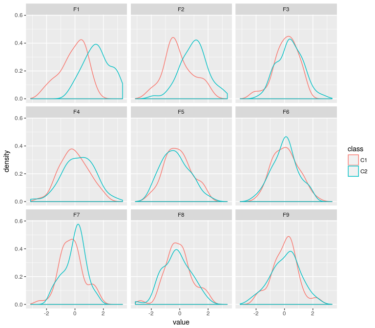

```r
gini_data %>%
  reshape2::melt(id.vars = "class", variable.name = "feature") %>%
  ggplot(aes(x = value, col = class)) +
    geom_density() +
    facet_wrap(~feature, ncol = 3)
```

# 4 Fit Random Forest Model

Let’s fit a model with all 9 features:

```r
set.seed(100)
full_model <- randomForest::randomForest(class ~ ., data = gini_data)
full_model
```

```
Call:
 randomForest(formula = class ~ ., data = gini_data)
               Type of random forest: classification
                     Number of trees: 500
No. of variables tried at each split: 3

        OOB estimate of  error rate: 18%
Confusion matrix:
   C1 C2 class.error
C1 42  8        0.16
C2 10 40        0.20
```

# 5 Variable Importance Scores

During bagging, variable importances scores for each tree are aggregated across all trees in the forest

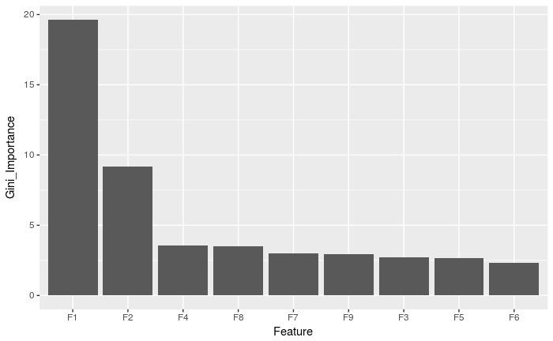

```r
randomForest::importance(full_model) %>%
  data.frame() %>%
  dplyr::rename(Gini_Importance = MeanDecreaseGini) %>%
  tibble::rownames_to_column("feat") %>%
    ggplot(aes(x = reorder(feat, -Gini_Importance), y = Gini_Importance)) +
    geom_bar(stat = "identity") +
    labs(x = "Feature")
```

# 6 OOB (out-of-bag) Samples

We are going to take advantage of an under-appreciated quality of random forest models, the out-of-bag samples, which can be thought of as `pseudo-cross-validation`. This property will help avoid over-fitting during feature selection process below, though in a high-stakes model building setting you might still want a proper hold-out set for performance testing.

## 6.1 Performance on OOB samples

```r
# OOB samples
rf_pred <- data.frame(truth = gini_data$class,
                      vote  = full_model$votes[, "C2"],
                      pred  = full_model$predicted)
# prediction results
head(rf_pred)
```

|  | truth | vote | pred |
| --- | --- | --- | --- |
| 1 | C1 | 0.3785311 | C1 |
| 2 | C1 | 0.1907514 | C1 |
| 3 | C1 | 0.4658385 | C1 |
| 4 | C1 | 0.4583333 | C1 |
| 5 | C1 | 0.3608247 | C1 |
| 6 | C1 | 0.4887640 | C1 |

```r
# model performance metrics
rf_pred %>% yardstick::conf_mat(truth = truth, estimate = pred)
```

```
          Truth
Prediction C1 C2
        C1 42 10
        C2  8 40
```

```r
rf_pred %>% yardstick::accuracy(truth = truth, estimate = pred)
```

```
[1] 0.82
```

```r
rf_pred %>% yardstick::sens(truth = truth, estimate = pred)
```

```
[1] 0.84
```

```r
rf_pred %>% yardstick::spec(truth = truth, estimate = pred)
```

```
[1] 0.8
```

```r
# ROC object
roc_obj <- pROC::roc(response  = rf_pred$truth,      # true class names
                     predictor = rf_pred$vote,       # predicted values
                     levels    = c("C1", "C2"))
# AUC
pROC::auc(roc_obj)
```

```
Area under the curve: 0.8926
```

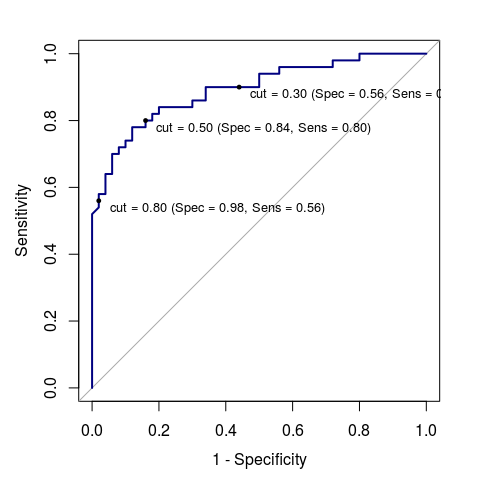

```r
# ROC curve
plot(roc_obj,
     col = "navy",
     print.thres = c(0.3, 0.5, 0.8),
     print.thres.cex = 0.8,
     legacy.axes = TRUE,
     print.thres.pattern = "cut = %.2f (Spec = %.2f, Sens = %.2f)")
```

# 7 Backward Feature Selection

Now that we have a sense of what a full model with all features might look like, can we determine the minimal set of features necessary to maintain a given performance (e.g. AUC).

```r
set.seed(100)                # match 1st model above
models   <- list()
features <- names(gini_data)[names(gini_data) != "class"]
for ( i in 1:length(features) ) {

  rf <- randomForest::randomForest(class ~ .,
                                   dplyr::select(gini_data,
                                                 class,
                                                 features))

  min_ft   <- rownames(rf$importance)[which.min(rf$importance)]
  features <- setdiff(features, min_ft)
  models[[paste0("Iter", i)]] <- rf

}
sapply(models, importance)
```

```
$Iter1
   MeanDecreaseGini
F1        19.642686
F2         9.206358
F3         2.703686
F4         3.561832
F5         2.670978
F6         2.301987
F7         2.990088
F8         3.490593
F9         2.960473

$Iter2
   MeanDecreaseGini
F1        17.994071
F2         9.580511
F3         3.513643
F4         4.072059
F5         3.418299
F7         3.527459
F8         4.026177
F9         3.358102

$Iter3
   MeanDecreaseGini
F1        18.877899
F2        10.594841
F3         3.955257
F4         4.661668
F5         3.367084
F7         3.686002
F8         4.329368

$Iter4
   MeanDecreaseGini
F1        20.429244
F2        10.803627
F3         4.607746
F4         4.835963
F7         4.127127
```

[output cut: 16 more lines]

```

$Iter7
   MeanDecreaseGini
F1         24.10264
F2         15.33552
F4         10.00012

$Iter8
   MeanDecreaseGini
F1         29.51913
F2         20.01719

$Iter9
   MeanDecreaseGini
F1         49.44468
```

# 8 Performance by Feature Step

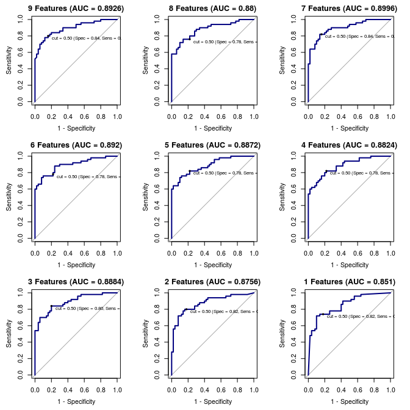

```r
par(mfrow = c(3, 3))
par(mgp = c(2, 0.75, 0), mar = c(2, 3, 2, 0))
purrr::map_dbl(models, function(mod) {
  .roc <- pROC::roc(gini_data$class,
                    mod$votes[, "C2"],
                    levels = c("C1", "C2"))
  n_feat <- nrow(mod$importance)
  auc    <- pROC::auc(.roc)
  plot(.roc, col = "navy",
       print.thres = 0.5,
       lwd = 2,
       main = stringr::str_glue("{n_feat} Features (AUC = {auc})"),
       print.thres.cex = 0.75,
       legacy.axes = TRUE,
       print.thres.pattern = "cut = %.2f (Spec = %.2f, Sens = %.2f)"
    )
  return(auc)
}) -> aucs
```

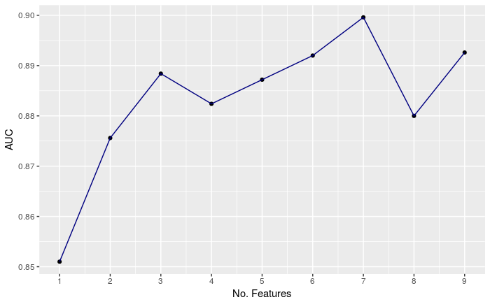

```r
qplot(rev(seq(aucs)), aucs) +
  labs(x = "No. Features", y = "AUC") +
  scale_x_continuous(breaks = seq(n_features)) +
  geom_line(color = "navy") +
  theme_gray()
```

# 9 Appendix: Theoretical Gini Max

From the `gini_max` function above, we can write a function to plot the `Gini Importance` with a rescaled y-axis reflecting `I` as a proportion of the theoretical maximum:

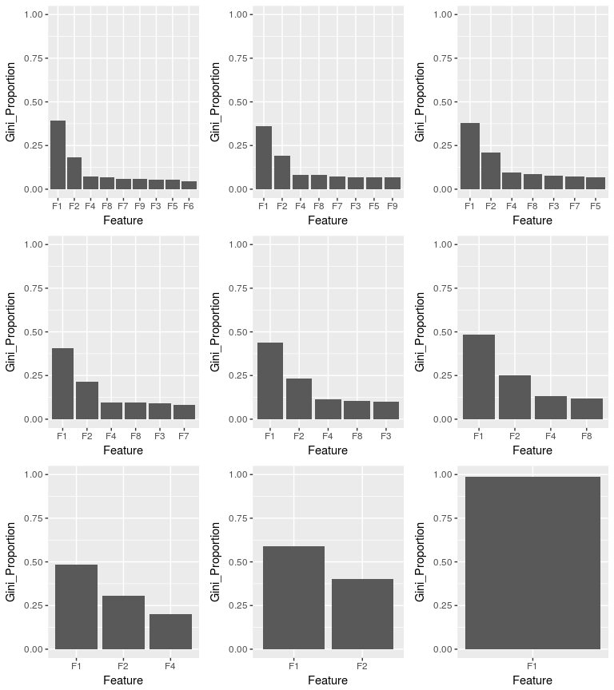

```r
plotGiniMax <- function(model, max) {

  randomForest::importance(model) %>%
    data.frame() %>%
    tibble::rownames_to_column("feat") %>%
    dplyr::mutate(Gini_Proportion = MeanDecreaseGini / max) %>%
      ggplot(aes(x = reorder(feat, -Gini_Proportion), y = Gini_Proportion)) +
      geom_bar(stat = "identity") +
      ylim(0, 1) +
      xlab("Feature")

}
max_g <- gini_max(gini_data$class)
purrr::map(models, plotGiniMax, max = max_g) %>%
  do.call(gridExtra::grid.arrange, .)
```

# 10 Resources

- From Leo Breiman, the inventor of the [Random Forest](https://www.stat.berkeley.edu/~breiman/RandomForests/cc_home.htm)
- Breiman, L. (2001). Random forests. *Machine Learning*. 45(1), 5-32.

[figure not shown]

**Sad But True**

Created on 2018-05-02 by the [rmarkdown package](https://github.com/rstudio/rmarkdown) (v1.9).